# 1 - Running a simple simulation

```r
library(landsepi)
```

## General presentation of the package

See `?lansdepi` for a complete description of the model, assumptions and available functions. See also the detailed list of parameters for a detailed description of all model parameters.

## Initialisation of simulation parameters

The function `createSimulParams()` will create a directory to store simulation outputs, and return an object of class `LandsepiParams` that will further contain all simulation parameters.

```r
simul_params <- createSimulParams(outputDir = getwd())
```

```
#> Created output directory : /tmp/RtmpIDfh2s/Rbuild27159d9b12e/landsepi/vignettes/simul_landsepi_2020-11-27_09-16-26
#> Seed for RGN set to : 1606464986
```

In the following, the object `simul_params` is to be updated with all simulation parameters using `set*()` functions. To help parameterisation, built-in parameters are available and may be loaded via `load*()` functions.

## Setting the seed and time parameters

A seed (for random number generator) is randomly generated when `simul_params` is initialised by `createSimulParams()`. If a specific seed is required, it can be set using the function `setSeed()`:

```r
simul_params@Seed
```

```
#> [1] 1606464986
```

```r
simul_params <- setSeed(simul_params, seed = 1)
```

```
#> Seed for RGN set to : 1
```

```r
simul_params@Seed
```

```
#> [1] 1
```

```r
simul_params <- setTime(simul_params, Nyears = 6, nTSpY = 120)
simul_params@TimeParam
```

```
#> $Nyears
#> [1] 6
#>
#> $nTSpY
#> [1] 120
```

## Setting pathogen parameters

Pathogen parameters must be stored in a list of aggressiveness components defined on a susceptible host for a pathogen genotype not adapted to resistance.

Buit-in parameterisation for rust pathogens of cereal crops is available using function `loadPathogen()`:

```r
basic_patho_param <- loadPathogen(disease = "rust")
basic_patho_param
```

```
#> $name
#> [1] "rust"
#>
#> $survival_prob
#> [1] 1e-04
#>
#> $repro_sex_prob
#> [1] 0
#>
#> $infection_rate
#> [1] 0.4
#>
#> $propagule_prod_rate
#> [1] 3.125
#>
#> $latent_period_exp
#> [1] 10
#>
#> $latent_period_var
#> [1] 9
#>
#> $infectious_period_exp
#> [1] 24
#>
#> $infectious_period_var
#> [1] 105
#>
#> $sigmoid_kappa
#> [1] 5.333
#>
#> $sigmoid_sigma
#> [1] 3
#>
#> $sigmoid_plateau
#> [1] 1
```

This list may be updated to change a specific parameter. For instance, to change the infection rate to 50%:

```r
basic_patho_param <- loadPathogen("rust")
basic_patho_param$infection_rate <- 0.5
basic_patho_param
```

```
#> $name
#> [1] "rust"
#>
#> $survival_prob
#> [1] 1e-04
#>
#> $repro_sex_prob
#> [1] 0
#>
#> $infection_rate
#> [1] 0.5
#>
#> $propagule_prod_rate
#> [1] 3.125
#>
#> $latent_period_exp
#> [1] 10
#>
#> $latent_period_var
#> [1] 9
#>
#> $infectious_period_exp
#> [1] 24
#>
#> $infectious_period_var
#> [1] 105
#>
#> $sigmoid_kappa
#> [1] 5.333
#>
#> $sigmoid_sigma
#> [1] 3
#>
#> $sigmoid_plateau
#> [1] 1
```

Finally, the list may be generated manually to control all parameters:

```r
basic_patho_param <- list(infection_rate = 0.4
                          , latent_period_exp = 10
                          , latent_period_var = 9
                          , propagule_prod_rate = 3.125
                          , infectious_period_exp = 24
                          , infectious_period_var = 105
                          , survival_prob = 1e-4
                          , repro_sex_prob = 0
                          , sigmoid_kappa = 5.333, sigmoid_sigma = 3, sigmoid_plateau = 1)
```

Then, the list is used to fuel the object `simul_params` via the function `setPathogen()`:

```r
simul_params <- setPathogen(simul_params, patho_params = basic_patho_param)
simul_params@Pathogen
```

```
#> $infection_rate
#> [1] 0.4
#>
#> $latent_period_exp
#> [1] 10
#>
#> $latent_period_var
#> [1] 9
#>
#> $propagule_prod_rate
#> [1] 3.125
#>
#> $infectious_period_exp
#> [1] 24
#>
#> $infectious_period_var
#> [1] 105
#>
#> $survival_prob
#> [1] 1e-04
#>
#> $repro_sex_prob
#> [1] 0
#>
#> $sigmoid_kappa
#> [1] 5.333
#>
#> $sigmoid_sigma
#> [1] 3
#>
#> $sigmoid_plateau
#> [1] 1
```

## Setting inoculum

The function `setInoculum()` updates `simul_params` with the probability for an individual to be infectious (i.e. state I) at the beginning of the simulation. Note that the inoculum is present on the first cultivar only (usually defined as the susceptible cultivar) and is not adapted to any plant resistance gene.

```r
simul_params <- setInoculum(simul_params, val = 5e-4)
simul_params@PI0
```

```
#> [1] 5e-04
```

## Setting the landscape and pathogen dispersal

The landscape (i.e. boundaries of fields) must be in shapefile format. Five built-in landscapes of about 150 fields are available using the function `loadLandscape()`:

```r
landscape <- loadLandscape(id = 1)
length(landscape)
```

```
#> [1] 155
```

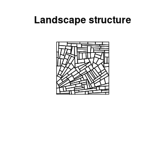

```r
plot(landscape, main = "Landscape structure")
```

*See also tutorial on how to parameterise landscape and dispersal to use your own landscape and compute your own dispersal matrices.*

Dispersal is given by a vectorised matrix giving the probability of dispersal from any field of the landscape to any other field. The size of the matrix must be the square of the number of fields in the landscape. It is thus specific to both the pathogen and the landscape. For rusts pathogens, a built-in dispersal matrix is available for each landscape using the function `loadDispersalPathogen()`:

```r
disp_patho <- loadDispersalPathogen(id = 1)
head(disp_patho)
```

```
#> [1] 8.814254e-01 9.525884e-04 7.079895e-10 1.594379e-10 3.285800e-06
#> [6] 3.634297e-11
```

```r
length(landscape)^2 == length(disp_patho)
```

```
#> [1] TRUE
```

Then, the object `simul_params` is updated with the landscape and dispersal matrix via the functions `setLandscape()` and `setDispersalPathogen()`, respectively:

```r
simul_params <- setLandscape(simul_params, land = landscape)
simul_params <- setDispersalPathogen(simul_params, mat = disp_patho)
```

## Setting croptypes, cultivars and resistance genes

Fields of the landscape are cultivated with different croptypes that can rotate through time; each croptype is composed of a pure cultivar or a mixture; and each cultivar may carry one or several resistance genes.

### Cultivars

Characteristics of each host genotype (i.e. cultivar) are summarised in a dataframe, which contains parameters representing the cultivar as if it was cultivated in a pure crop. **Note that the name of the cultivar cannot accept spaces.**  
A buit-in parameterisation for classical types of cultivars is available using `loadCultivar()` to generate each line of the dataframe. The only difference between the types “growingHost” and “nongrowingHost” is the absence of growth in the later. Type “nonCrop” allows the simulation of forest, fallows, etc. i.e. everything that is not planted, does not cost anything and does not yield anything (with regard to the subject of the study).  
**It is advised to implement a susceptible cultivar at first line of the dataframe to allow pathogen initial inoculation.**

```r
cultivar1 <- loadCultivar(name = "Susceptible", type = "growingHost")
cultivar2 <- loadCultivar(name = "Resistant1", type = "growingHost")
cultivar3 <- loadCultivar(name = "Resistant2", type = "growingHost")
cultivar4 <- loadCultivar(name = "Resistant3", type = "nongrowingHost")
cultivar5 <- loadCultivar(name = "Forest", type = "nonCrop")
cultivars <- data.frame(rbind(cultivar1, cultivar2, cultivar3, cultivar4, cultivar5)
                        , stringsAsFactors = FALSE)
cultivars
```

```
#>   cultivarName initial_density max_density growth_rate reproduction_rate
#> 1  Susceptible             0.1           2         0.1                 0
#> 2   Resistant1             0.1           2         0.1                 0
#> 3   Resistant2             0.1           2         0.1                 0
#> 4   Resistant3             2.0           2         0.0                 0
#> 5       Forest             0.0           2         0.0                 0
#>   death_rate yield_H yield_L yield_I yield_R production_cost market_value
#> 1          0     2.5       0       0       0             225          200
#> 2          0     2.5       0       0       0             225          200
#> 3          0     2.5       0       0       0             225          200
#> 4          0     2.5       0       0       0             225          200
#> 5          0     0.0       0       0       0               0            0
```

Similarly as pathogen parameters, characteristics of the cultivars may be updated as required. For example, to change the growth rate of the susceptible cultivar:

```r
cultivars[cultivars$cultivarName == "Susceptible", "growth_rate"] <- 0.2
cultivars
```

```
#>   cultivarName initial_density max_density growth_rate reproduction_rate
#> 1  Susceptible             0.1           2         0.2                 0
#> 2   Resistant1             0.1           2         0.1                 0
#> 3   Resistant2             0.1           2         0.1                 0
#> 4   Resistant3             2.0           2         0.0                 0
#> 5       Forest             0.0           2         0.0                 0
#>   death_rate yield_H yield_L yield_I yield_R production_cost market_value
#> 1          0     2.5       0       0       0             225          200
#> 2          0     2.5       0       0       0             225          200
#> 3          0     2.5       0       0       0             225          200
#> 4          0     2.5       0       0       0             225          200
#> 5          0     0.0       0       0       0               0            0
```

Finally, the dataframe `cultivars` can also be generated entirely from scratch:

```r
cultivars_new <- data.frame(cultivarName = c("Susceptible", "Resistant"),
                            initial_density =   c(0.1, 0.2),
                            max_density =       c(2.0, 3.0),
                            growth_rate =       c(0.1, 0.2),
                            reproduction_rate = c(0.0, 0.0),
                            death_rate =        c(0.0, 0.0),
                            yield_H =           c(2.5, 2.0),
                            yield_L =           c(0.0, 0.0),
                            yield_I =           c(0.0, 0.0),
                            yield_R =           c(0.0, 0.0),
                            production_cost =   c(225, 300),
                            market_value =      c(200, 150),
                            stringsAsFactors = FALSE)
cultivars_new
```

```
#>   cultivarName initial_density max_density growth_rate reproduction_rate
#> 1  Susceptible             0.1           2         0.1                 0
#> 2    Resistant             0.2           3         0.2                 0
#>   death_rate yield_H yield_L yield_I yield_R production_cost market_value
#> 1          0     2.5       0       0       0             225          200
#> 2          0     2.0       0       0       0             300          150
```

### Resistance genes

Characteristics of each plant resistance gene and each corresponding pathogenicity gene are summarised in a dataframe.  
A built-in parameterisation for classical resistance sources is available using `loadGene()` to generate each line of the dataframe. Type “majorGene” is for completely efficient resistance to which pathogen may adapt via a single mutation. Type “APR” stands for Adult Plant Resistance, i.e. a major gene which activates after a delay after planting, and type “QTL” is a partially efficient resistance source to which the pathogen may adapt gradually. The type “immunity” code for a completely efficient resistance gene that cannot be overcome, in such a way that infection is totally impossible; it is helpful to parameterise non-host cultivars.

```r
gene1 <- loadGene(name = "MG 1", type = "majorGene")
gene2 <- loadGene(name = "Lr34", type = "APR")
gene3 <- loadGene(name = "gene 3", type = "QTL")
gene4 <- loadGene(name = "nonhost resistance", type = "immunity")
genes <- data.frame(rbind(gene1, gene2, gene3, gene4), stringsAsFactors = FALSE)
genes
```

```
#>             geneName efficiency time_to_activ_exp time_to_activ_var
#> 1               MG 1        1.0                 0                 0
#> 2               Lr34        1.0                30                30
#> 3             gene 3        0.5                 0                 0
#> 4 nonhost resistance        1.0                 0                 0
#>   mutation_prob Nlevels_aggressiveness fitness_cost tradeoff_strength
#> 1         1e-07                      2          0.5                 1
#> 2         1e-07                      2          0.5                 1
#> 3         1e-04                      6          0.5                 1
#> 4         0e+00                      1          0.0                 1
#>   target_trait
#> 1           IR
#> 2           IR
#> 3           IR
#> 4           IR
```

Similarly as pathogen parameters, characteristics of the genes may be updated as required. For example, to change the mutation probability of the pathogen with regard to its adaptation to “MG 1”:

```r
genes[genes$geneName == "MG 1", "mutation_prob"] <- 1e-3
genes
```

```
#>             geneName efficiency time_to_activ_exp time_to_activ_var
#> 1               MG 1        1.0                 0                 0
#> 2               Lr34        1.0                30                30
#> 3             gene 3        0.5                 0                 0
#> 4 nonhost resistance        1.0                 0                 0
#>   mutation_prob Nlevels_aggressiveness fitness_cost tradeoff_strength
#> 1         1e-03                      2          0.5                 1
#> 2         1e-07                      2          0.5                 1
#> 3         1e-04                      6          0.5                 1
#> 4         0e+00                      1          0.0                 1
#>   target_trait
#> 1           IR
#> 2           IR
#> 3           IR
#> 4           IR
```

Finally, the dataframe `genes` can also be generated entirely from scratch:

```r
genes_new <- data.frame(geneName =               c("MG1", "MG2"),
                        efficiency =             c(1.0  , 0.8  ),
                        time_to_activ_exp =      c(0.0  , 0.0  ),
                        time_to_activ_var =      c(0.0  , 0.0  ),
                        mutation_prob =          c(1E-7 , 1E-4),
                        Nlevels_aggressiveness = c(2    , 2    ),
                        fitness_cost =           c(0.50 , 0.75 ),
                        tradeoff_strength =      c(1.0  , 1.0  ),
                        target_trait =           c("IR" , "LAT"),
                        stringsAsFactors = FALSE)
genes_new
```

```
#>   geneName efficiency time_to_activ_exp time_to_activ_var mutation_prob
#> 1      MG1        1.0                 0                 0         1e-07
#> 2      MG2        0.8                 0                 0         1e-04
#>   Nlevels_aggressiveness fitness_cost tradeoff_strength target_trait
#> 1                      2         0.50                 1           IR
#> 2                      2         0.75                 1          LAT
```

Note that the column “efficiency” refers to the percentage of reduction of the targeted aggressiveness component on hosts carrying the gene. For example, a 80% efficient resistance against infection rate (target_trait = “IR”) means that the infection rate of a non-adapted pathogen is reduced by 80% on a resistant host compared to what it is on a susceptible host. For resistances targetting the latent period, the percentage of reduction is applied to the inverse of the latent period in such a way that latent period is higher in resistant than in susceptible hosts.

### Allocating genes to cultivars

The object `simul_params` can be updated with `setGenes()` and `setCultivars()`:

```r
simul_params <- setGenes(simul_params, dfGenes = genes)
simul_params <- setCultivars(simul_params, dfCultivars = cultivars)
simul_params@Genes
```

```
#>                              geneName efficiency time_to_activ_exp
#> MG 1                             MG 1        1.0                 0
#> Lr34                             Lr34        1.0                30
#> gene 3                         gene 3        0.5                 0
#> nonhost resistance nonhost resistance        1.0                 0
#>                    time_to_activ_var mutation_prob Nlevels_aggressiveness
#> MG 1                               0         1e-03                      2
#> Lr34                              30         1e-07                      2
#> gene 3                             0         1e-04                      6
#> nonhost resistance                 0         0e+00                      1
#>                    fitness_cost tradeoff_strength target_trait
#> MG 1                        0.5                 1           IR
#> Lr34                        0.5                 1           IR
#> gene 3                      0.5                 1           IR
#> nonhost resistance          0.0                 1           IR
```

```r
simul_params@Cultivars
```

```
#>             cultivarName initial_density max_density growth_rate
#> Susceptible  Susceptible             0.1           2         0.2
#> Resistant1    Resistant1             0.1           2         0.1
#> Resistant2    Resistant2             0.1           2         0.1
#> Resistant3    Resistant3             2.0           2         0.0
#> Forest            Forest             0.0           2         0.0
#>             reproduction_rate death_rate yield_H yield_L yield_I yield_R
#> Susceptible                 0          0     2.5       0       0       0
#> Resistant1                  0          0     2.5       0       0       0
#> Resistant2                  0          0     2.5       0       0       0
#> Resistant3                  0          0     2.5       0       0       0
#> Forest                      0          0     0.0       0       0       0
#>             production_cost market_value
#> Susceptible             225          200
#> Resistant1              225          200
#> Resistant2              225          200
#> Resistant3              225          200
#> Forest                    0            0
```

Then the function `allocateCultivarGenes()` allows the attribution of resistance genes to cultivars:

```r
simul_params <- allocateCultivarGenes(simul_params
                                      , cultivarName = "Resistant1"
                                      , listGenesNames = c("MG 1"))
simul_params <- allocateCultivarGenes(simul_params
                                      , cultivarName = "Resistant2"
                                      , listGenesNames = c("Lr34", "gene 3"))
simul_params <- allocateCultivarGenes(simul_params
                                      , cultivarName = "Resistant3"
                                      , listGenesNames = c("nonhost resistance"))
simul_params@Cultivars
```

```
#>             cultivarName initial_density max_density growth_rate
#> Susceptible  Susceptible             0.1           2         0.2
#> Resistant1    Resistant1             0.1           2         0.1
#> Resistant2    Resistant2             0.1           2         0.1
#> Resistant3    Resistant3             2.0           2         0.0
#> Forest            Forest             0.0           2         0.0
#>             reproduction_rate death_rate yield_H yield_L yield_I yield_R
#> Susceptible                 0          0     2.5       0       0       0
#> Resistant1                  0          0     2.5       0       0       0
#> Resistant2                  0          0     2.5       0       0       0
#> Resistant3                  0          0     2.5       0       0       0
#> Forest                      0          0     0.0       0       0       0
#>             production_cost market_value
#> Susceptible             225          200
#> Resistant1              225          200
#> Resistant2              225          200
#> Resistant3              225          200
#> Forest                    0            0
```

With this example of parameterisation:  
- “Susceptible” is a susceptible cultivar (initially infected by a wild-type pathogen)  
- “Resistant1” is a mono-resistant cultivar  
- “Resistant2” is a pyramided cultivar  
- “Resistant3” is a nonhost cultivar  
- “Forest” is not a crop.  
Infection is impossible on both “Resistance3” and “Forest”, but the former will be considered for host growth, yield, production costs and benefits, whereas the latter won’t.

### Allocating cultivars to croptypes

Characteristics of each croptype (a croptype is a set of hosts cultivated in a field with specific proportions) are summarised in a dataframe.  
A buit-in parameterisation for classical croptypes is available using `loadCroptypes()` to generate the whole table filled with zeros:

```r
croptypes <- loadCroptypes(simul_params, names = c("Susceptible crop"
                                                   , "Pure resistant crop"
                                                   , "Mixture"
                                                   , "Other"))
croptypes
```

```
#>   croptypeID        croptypeName Susceptible Resistant1 Resistant2 Resistant3
#> 1          0    Susceptible crop           0          0          0          0
#> 2          1 Pure resistant crop           0          0          0          0
#> 3          2             Mixture           0          0          0          0
#> 4          3               Other           0          0          0          0
#>   Forest
#> 1      0
#> 2      0
#> 3      0
#> 4      0
```

Then `croptype` is updated by `allocateCroptypeCultivars()` to specify the composition of every croptype with regard to cultivars (and proportion for mixtures):

```r
croptypes <- allocateCroptypeCultivars(croptypes
                                       , croptypeName = "Susceptible crop"
                                       , cultivarsInCroptype = "Susceptible")
croptypes <- allocateCroptypeCultivars(croptypes
                                       , croptypeName = "Pure resistant crop"
                                       , cultivarsInCroptype = "Resistant1")
croptypes <- allocateCroptypeCultivars(croptypes
                                       , croptypeName = "Mixture"
                                       , cultivarsInCroptype = c("Resistant2","Resistant3")
                                       , prop = c(0.4, 0.6))
croptypes <- allocateCroptypeCultivars(croptypes
                                       , croptypeName = "Other"
                                       , cultivarsInCroptype = "Forest")
croptypes
```

```
#>   croptypeID        croptypeName Susceptible Resistant1 Resistant2 Resistant3
#> 1          0    Susceptible crop           1          0        0.0        0.0
#> 2          1 Pure resistant crop           0          1        0.0        0.0
#> 3          2             Mixture           0          0        0.4        0.6
#> 4          3               Other           0          0        0.0        0.0
#>   Forest
#> 1      0
#> 2      0
#> 3      0
#> 4      1
```

Finally the object `simul_params` is updated using `setCroptypes()`:

```r
simul_params <- setCroptypes(simul_params, dfCroptypes = croptypes)
simul_params@Croptypes
```

```
#>   croptypeID        croptypeName Susceptible Resistant1 Resistant2 Resistant3
#> 0          0    Susceptible crop           1          0        0.0        0.0
#> 1          1 Pure resistant crop           0          1        0.0        0.0
#> 2          2             Mixture           0          0        0.4        0.6
#> 3          3               Other           0          0        0.0        0.0
#>   Forest
#> 0      0
#> 1      0
#> 2      0
#> 3      1
```

Alternatively, the dataframe `croptypes` can be generated from scratch:

```r
croptypes <- data.frame(croptypeID = c(0, 1, 2, 3)
                        , croptypeName = c("Susceptible crop"
                                           , "Pure resistant crop"
                                           , "Mixture"
                                           , "Other")
                        , Susceptible = c(1,0,0  ,0)
                        , Resistant1  = c(0,1,0  ,0)
                        , Resistant2  = c(0,0,0.5,0)
                        , Resistant3  = c(0,0,0.5,0)
                        , Forest      = c(0,0,0  ,1)
                        , stringsAsFactors = FALSE)
simul_params <- setCroptypes(simul_params, croptypes)
```

### Allocating croptypes to fields of the landscape

The function `allocateLandscapeCroptypes()` manages the allocation of croptypes in time (for rotations of different croptypes on the same fields) and space (for mosaic of fields cultivated with different croptypes). See `?allocateLandscapeCroptypes` for help in parameters.  
Briefly, a rotation sequence is defined by a list. Each element of this list is a vector containing the indices of the croptypes that are cultivated simultaneously in the landscape. The “rotation_period” parameter defines the duration before switching from one element of “rotation_sequence” to the next. For each element of “rotation_sequence” is associated a vector of proportions of each croptype in the landscape (parameter “prop”). The parameter “aggreg” controls the level of spatial aggregation between croptypes.

For example, to generate a landscape whose surface is composed of 1/3 of forests, 1/3 of susceptible crop, and 1/3 of fields where a pure resistant crop is alternated with a mixture every two years:

```r
# croptypeIDs cultivated in each element of the rotation sequence:
rotation_sequence <- list(c(0,1,3), c(0,2,3))
rotation_period <- 2  # number of years before rotation of the landscape
prop <- list(rep(1/3, 3), rep(1/3, 3))  # proportion (in surface) of each croptype
aggreg <- 1    # level of spatial aggregation
simul_params <- allocateLandscapeCroptypes(simul_params
                                           , rotation_period = rotation_period
                                           , rotation_sequence = rotation_sequence
                                           , prop = prop
                                           , aggreg = aggreg
                                           , graphic = FALSE)
# plot(simul_params@Landscape)
```

## Choosing output variables

Several epidemiological, evolutionary and economic outputs can be generated by landsepi and represented in text files (`writeTXT=TRUE`), graphics (`graphic=TRUE`) and a video (`videoMP4=TRUE`).  
See `?epid_output` and `?evol_output` for details on the different output variables.

> Possible evolutionary outputs include:  
> - **“evol_patho”**: Dynamics of pathogen genotype frequencies  
> - **“evol_aggr”**: Evolution of pathogen aggressiveness  
> - **“durability”**: Durability of resistance genes  
> - **“all”**: compute all these outputs (default)  
> - **""**: none of these outputs will be generated.

A list of outputs can be generated using `loadOutputs()`:

```r
outputlist <- loadOutputs(epid_outputs = "all", evol_outputs = "all")
outputlist
```

```
#> $epid_outputs
#> [1] "all"
#>
#> $evol_outputs
#> [1] "all"
#>
#> $thres_breakdown
#> [1] 50000
#>
#> $GLAnoDis
#> [1] 1.48315
#>
#> $audpc100S
#> [1] 0.38
```

Then `simul_params` can be updated via `setOutputs()`:

```r
simul_params <- setOutputs(simul_params, outputlist)
```

*See also tutorial on how to run a numerical experimental design to compute your own output variables and to run several simulations within an experimental design*

## Running the simulation

The functions `checkSimulParams()` and `saveDeploymentStrategy()` check simulation parameters and save the object `simul_params` (which contains all parameters associated with the deployment strategy) into a GPKG file, respectively.

```r
checkSimulParams(simul_params)
simul_params <- saveDeploymentStrategy(simul_params)
```

Then, the function `runSimul()` launches the simulation. Use `?runSimul` to get all available options.

```r
runSimul(simul_params, graphic = TRUE, videoMP4 = FALSE)
```